# TidyTuesday Week 21 - California Fires

Roberto Preste

2018-09-04

```r
library(tidyverse)
library(funModeling)
library(gridExtra)
```

This is the original data provided by [BuzzFeed](https://github.com/BuzzFeedNews/2018-07-wildfire-trends) from their article [“How A Booming Population And Climate Change Made California’s Wildfires Worse Than Ever”](https://www.buzzfeednews.com/article/peteraldhous/california-wildfires-people-climate).

```r
head(df)
```

| id | objectid | year | state | agency | unit_id | fire_name | inc_num | alarm_date | cont_date | cause | comments | report_ac | gis_acres | c_method | objective | fire_num | shape_length | shape_area | fire_cause | plot_date |
| --- | --- | --- | --- | --- | --- | --- | --- | --- | --- | --- | --- | --- | --- | --- | --- | --- | --- | --- | --- | --- |
| 1 | 1 | 2007 | CA | CCO | LAC | OCTOBER | 246393 | 2007-10-21 | 2007-10-23 | 14 | NA | NA | 25.73671 | 8 | 1 | 233414 | 1902.439 | 104152.8 | Unknown | 2017-10-21 |
| 2 | 2 | 2007 | CA | CCO | LAC | MAGIC | 233077 | 2007-10-22 | 2007-10-25 | 14 | NA | NA | 2824.87720 | 8 | 1 | 233077 | 20407.966 | 11431872.5 | Unknown | 2017-10-22 |
| 3 | 3 | 2007 | CA | USF | ANF | RANCH | 166 | 2007-10-20 | 2007-11-15 | 2 | NA | 54716 | 58410.33594 | 7 | 1 | 166 | 169150.716 | 236378245.2 | Human | 2017-10-20 |
| 4 | 4 | 2007 | CA | CCO | LAC | EMMA | 201384 | 2007-09-11 | 2007-09-11 | 14 | NA | NA | 172.21495 | 8 | 1 | 201384 | 6117.777 | 696929.2 | Unknown | 2017-09-11 |
| 5 | 5 | 2007 | CA | CCO | LAC | CORRAL | 259483 | 2007-11-24 | 2007-11-27 | 14 | NA | NA | 4707.99707 | 8 | 1 | 259483 | 22907.182 | 19052588.5 | Unknown | 2017-11-24 |
| 6 | 6 | 2007 | CA | CCO | LAC | GORMAN | 109398 | 2007-05-19 | 2007-05-22 | 14 | NA | NA | 2373.84497 | 8 | 1 | 109398 | 19693.209 | 9606609.4 | Unknown | 2017-05-19 |

## Data exploration

Let’s have a quick view at the structure and content of this dataset.

```r
df %>% df_status()
```

| variable | q_zeros | p_zeros | q_na | p_na | q_inf | p_inf | type | unique |
| --- | --- | --- | --- | --- | --- | --- | --- | --- |
| id | 0 | 0.00 | 0 | 0.00 | 0 | 0 | integer | 14847 |
| objectid | 0 | 0.00 | 0 | 0.00 | 0 | 0 | integer | 14847 |
| year | 0 | 0.00 | 0 | 0.00 | 0 | 0 | integer | 68 |
| state | 0 | 0.00 | 3 | 0.02 | 0 | 0 | character | 4 |
| agency | 0 | 0.00 | 5 | 0.03 | 0 | 0 | character | 10 |
| unit_id | 0 | 0.00 | 10 | 0.07 | 0 | 0 | character | 88 |
| fire_name | 0 | 0.00 | 2903 | 19.55 | 0 | 0 | character | 7411 |
| inc_num | 7681 | 51.73 | 585 | 3.94 | 0 | 0 | character | 5004 |
| alarm_date | 0 | 0.00 | 1617 | 10.89 | 0 | 0 | Date | 6677 |
| cont_date | 0 | 0.00 | 7486 | 50.42 | 0 | 0 | Date | 4153 |

[output cut: 11 more lines]

Let’s first check the number of human and natural fires throughout the years.

```r
fire_type_years <- df %>%
    group_by(year, fire_cause) %>%
    summarise(fires = n())
```

We will plot the same data using a simple line plot and a smooth line plot, to avoid overplotting and visualize better the trends.

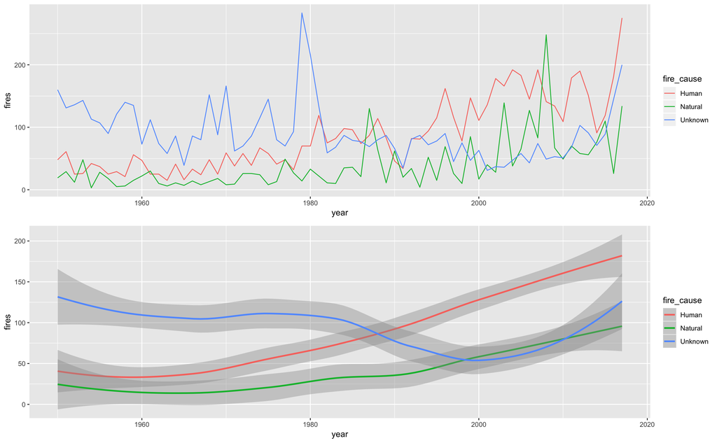

```r
line_1 <- fire_type_years %>%
    ggplot(aes(x = year, y = fires, colour = fire_cause)) +
    geom_line()
smooth_1 <- fire_type_years %>%
    ggplot(aes(x = year, y = fires, colour = fire_cause)) +
    geom_smooth()
grid.arrange(line_1, smooth_1, nrow = 2)
```

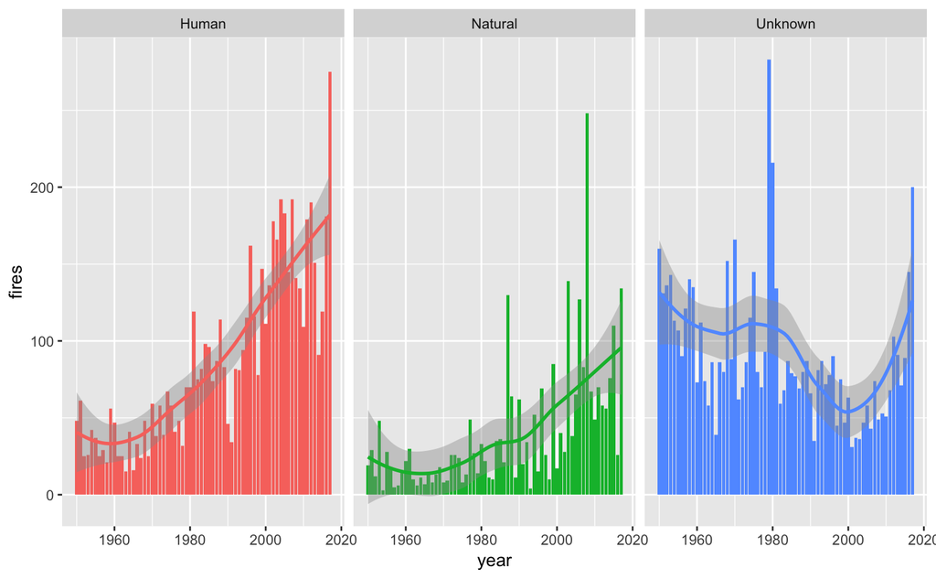

```r
fire_type_years %>%
    ggplot(aes(x = year, y = fires)) +
    geom_col(aes(fill = fire_cause), position = "dodge") +
    geom_smooth(aes(color = fire_cause)) +
    facet_grid(~ fire_cause) +
    guides(fill = FALSE, color = FALSE)
```

We can clearly identify that in recent years, human-caused fires have definitely outnumbered the natural ones!

Let’s see if this increase also regards the burnt area of a fire.

```r
fire_area_years <- df %>%
    group_by(year, fire_cause) %>%
    summarise(tot_area_burnt = sum(shape_area),
              mean_area_burnt = mean(shape_area))
```

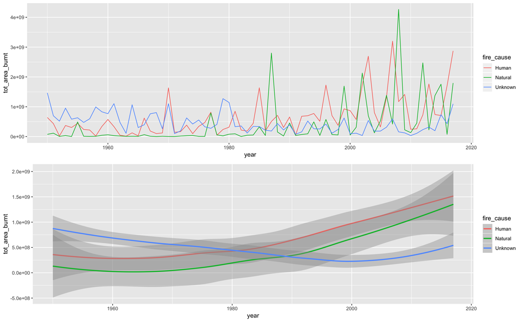

```r
line_2 <- fire_area_years %>%
    ggplot(aes(x = year, y = tot_area_burnt, color = fire_cause)) +
    geom_line()
smooth_2 <- fire_area_years %>%
    ggplot(aes(x = year, y = tot_area_burnt, color = fire_cause)) +
    geom_smooth()
grid.arrange(line_2, smooth_2, nrow = 2)
```

Unfortunately, also the total area burnt each year increased over the years, although with no visible difference between natural- and human-caused fires.  
We may interested in the **mean** area burnt by each fire, though.

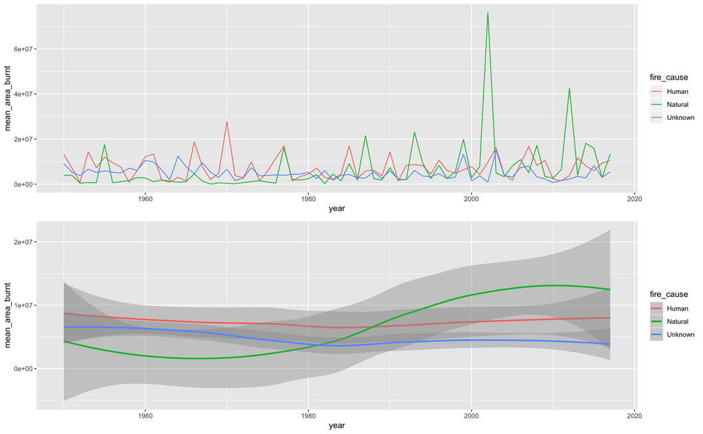

```r
line_3 <- fire_area_years %>%
    ggplot(aes(x = year, y = mean_area_burnt, colour = fire_cause)) +
    geom_line()
smooth_3 <- fire_area_years %>%
    ggplot(aes(x = year, y = mean_area_burnt, colour = fire_cause)) +
    geom_smooth()
grid.arrange(line_3, smooth_3, nrow = 2)
```

From the first line plot, we can see that the mean area burnt by each fire was roughly the same over the years; in this case the smooth plot is not very useful, because it’s biased by the two peaks visible in the first graph. They are due to the 2002 [Biscuit Fire](https://en.wikipedia.org/wiki/Biscuit_Fire) and the 2012 [Rush Fire](https://en.wikipedia.org/wiki/Rush_Fire), which destroyed an impressive number of acres during their life.  
Notably, the Biscuit fire caused more destruction alone than all the other fires (natural and human) in 2002!

```r
biscuit_area <- df %>%
    filter(fire_name == "BISCUIT", year == 2002) %>%
    select(shape_area)
others_area <- df %>%
    filter(fire_name != "BISCUIT", fire_name != "RUSH", year == 2002) %>%
    summarise(tot = sum(shape_area))
area_comp <- tibble(fire_name = c("Biscuit", "Others"),
                    area_burnt = c(biscuit_area[[1]], others_area[[1]]))
```

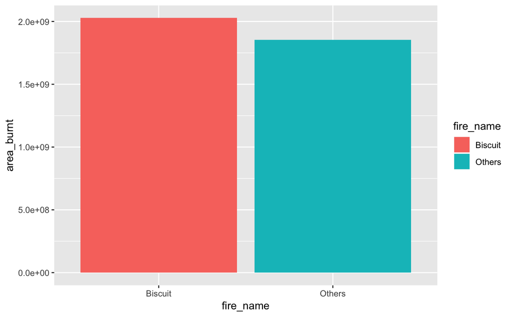

```r
area_comp %>%
    ggplot(aes(x = fire_name, y = area_burnt, fill = fire_name)) +
    geom_col()
```

```r
fire_area_years %>% filter(year == 2012)
```

| year | fire_cause | tot_area_burnt | mean_area_burnt |
| --- | --- | --- | --- |
| 2012 | Human | 727043487 | 3826545 |
| 2012 | Natural | 2471282941 | 42608327 |
| 2012 | Unknown | 232252737 | 2254881 |

```r
df %>% filter(year == 2012) %>% arrange(desc(shape_area))
```

| id | objectid | year | state | agency | unit_id | fire_name | inc_num | alarm_date | cont_date | cause | comments | report_ac | gis_acres | c_method | objective | fire_num | shape_length | shape_area | fire_cause | plot_date |
| --- | --- | --- | --- | --- | --- | --- | --- | --- | --- | --- | --- | --- | --- | --- | --- | --- | --- | --- | --- | --- |
| 12298 | 17383 | 2012 | CA | BLM | NOD | RUSH | 3490 | 2012-08-12 | 2012-10-22 | 1 | NA | 3.155770e+05 | 3.155115e+05 | 3 | 1 | NA | 414346.36296 | 1.276830e+09 | Natural | 2017-08-12 |
| 12401 | 17486 | 2012 | OR | USF | FNF | BARRY POINT | 120680 | 2012-08-06 | 2012-09-17 | 1 | OR-FWF-120680 this line is a combo of firelines and fire edges | 9.307100e+04 | 9.294453e+04 | 7 | 1 | NA | 185385.39552 | 3.761332e+08 | Natural | 2017-08-06 |
| 12306 | 17391 | 2012 | CA | USF | PNF | CHIPS | 1001 | 2012-07-28 | 2012-08-31 | 4 | Escaped campfire in the Chips Creek drainage ran to the NW to Lake Almanor. | 7.543100e+04 | 7.634971e+04 | 8 | 1 | NA | 156106.65117 | 3.089763e+08 | Human | 2017-07-28 |
| 12327 | 17412 | 2012 | CA | USF | SHF | BAGLEY | 2744 | 2012-08-18 | 2012-10-29 | 1 | NA | 4.601100e+04 | 4.604015e+04 | 8 | 1 | NA | 88198.43928 | 1.863179e+08 | Natural | 2017-08-18 |
| 12264 | 17349 | 2012 | CA | USF | MNF | NORTH PASS | 1446 | 2012-06-18 | 2012-09-27 | 1 | NA | 4.198300e+04 | 4.181252e+04 | 7 | 1 | NA | 85213.68510 | 1.692093e+08 | Natural | 2017-06-18 |
| 12263 | 17348 | 2012 | CA | USF | MNF | MILL | 1109 | 2012-07-07 | 2012-07-18 | 9 | NA | 2.905200e+04 | 2.952545e+04 | 3 | 1 | NA | 60310.85832 | 1.194853e+08 | Human | 2017-07-07 |
| 13461 | 18626 | 2012 | CA | NPS | LNP | READING | 3115 | 2012-07-23 | 2012-11-13 | 14 | GEOMAC Comments: FIMT | NA | 2.807320e+04 | 8 | 1 | NA | 65303.68933 | 1.136082e+08 | Unknown | 2017-07-23 |
| 12395 | 17480 | 2012 | CA | CDF | TGU | PONDEROSA | 6696 | 2012-08-18 | 2012-10-12 | 1 | NA | 2.767600e+04 | 2.767038e+04 | 1 | 1 | NA | 77658.98875 | 1.119780e+08 | Natural | 2017-08-18 |
| 12183 | 17268 | 2012 | CA | USF | KNF | GOFF | 5659 | 2012-08-05 | 2012-10-01 | 1 | part of the Fort Complex | 2.228300e+04 | 2.226695e+04 | 7 | 1 | NA | 124425.15949 | 9.011113e+07 | Natural | 2017-08-05 |
| 12235 | 17320 | 2012 | CA | CDF | LNU | SIXTEEN_COMPLEX | 7072 | 2012-09-04 | 2012-09-15 | 7 | NA | 1.794400e+04 | 1.794215e+04 | 1 | 1 | NA | 65417.61632 | 7.260929e+07 | Human | 2017-09-04 |

[output cut: 341 more lines]

```r
df %>% select(alarm_date) %>% is.na()
```

[output not shown]